## Histograms

Histograms show the distribution of a continuous variable by showing the frequency of different values within specified intervals. In ggplot2, the `geom_histogram()` function is used to produce histograms. The data used in the examples comes from the `{palmerpenguins}` package.

### A simple histogram

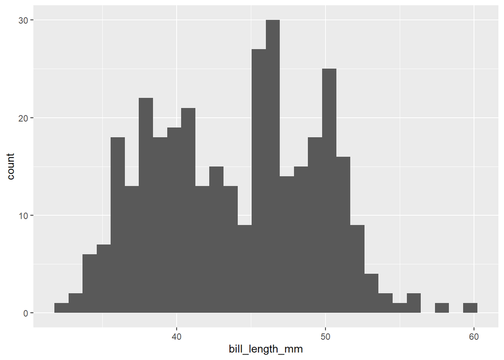

```r
ggplot(data = penguins,
       mapping = aes(x = bill_length_mm)) +
  geom_histogram()
```

### Setting the bin width

By default, {ggplot2} splits the data into 30 equally sized bins. This can be changed in two ways: (i) specifying the number of bins using the `bins` argument in `geom_histogram()`, or (ii) specifying the size of the interval using the `binwidth` argument in `geom_histogram()`.

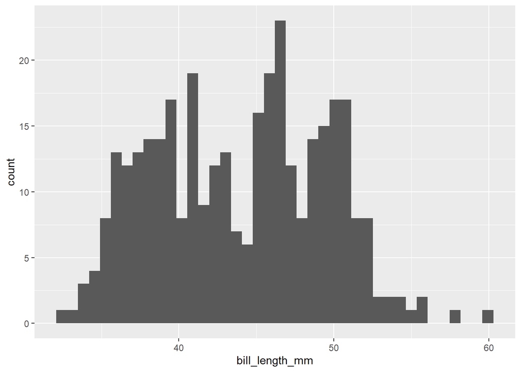

```r
ggplot(data = penguins,
       mapping = aes(x = bill_length_mm)) +
  geom_histogram(bins = 40)
```

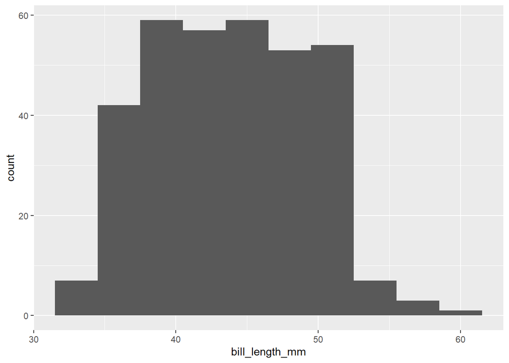

```r
ggplot(data = penguins,
       mapping = aes(x = bill_length_mm)) +
  geom_histogram(binwidth = 3)
```

### Adding colour

There are two ways to add colour to histograms: (i) using `colour` (or `color`) which changes the colour of the outline of histogram columns; (ii) using `fill` which changes the colour of the inner area of the histogram columns. If `colour` or `fill` is set outside the `aes()` function, it must be a valid colour name, and will set the same colour for all histograms. If `colour` or `fill` is set inside the `aes()` function, the colours will change based on the value of a variable. Here, the `fill` changes based on the `species`, creating three (differently coloured) histograms.

When plotting multiple histogram on the same plot, it is often a good idea to increase the transparency of the fill colour to make sure that all layers can be seen. This is achieved using the `alpha` argument within `geom_histogram()`. Since the same transparency is desired for all histograms, it is set outside the `aes()` function. An `alpha` value of `0` is completely transparent, whilst a value of `1` is solid colour.

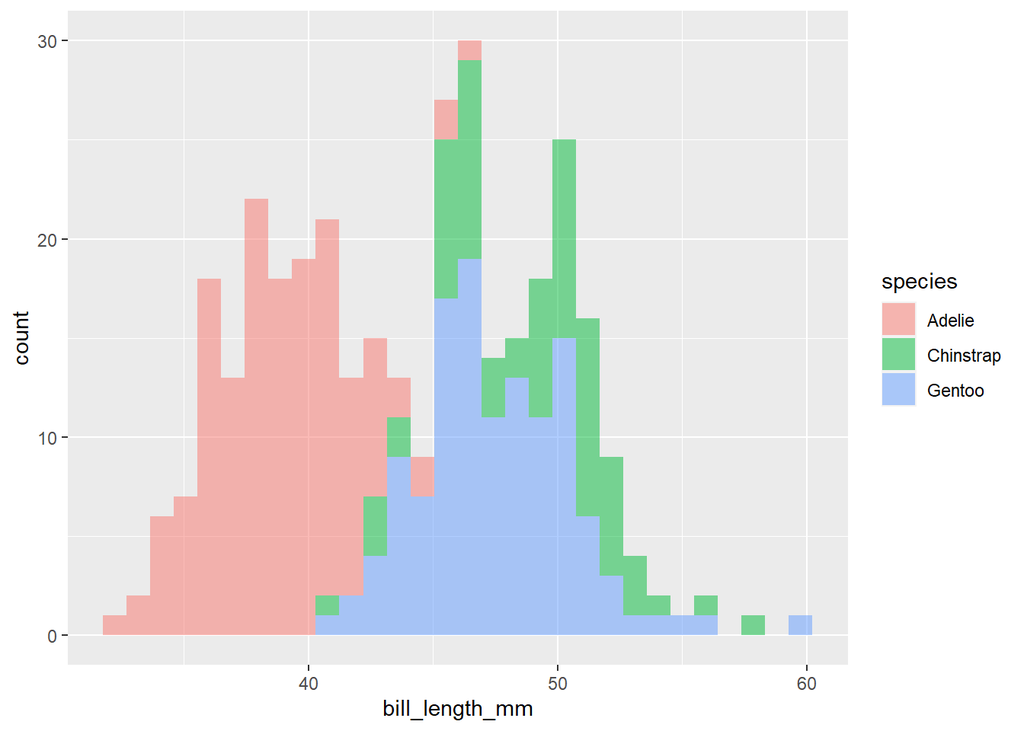

```r
ggplot(data = penguins,
       mapping = aes(x = bill_length_mm,
                     fill = species)) +
  geom_histogram(alpha = 0.5)
```

### Facetting

Rather than displaying multiple histograms on the **same** plot, `facet_wrap()` can be used to **facet** create a separate histogram for each category. Note the `vars()` function wrapping around the variable when specifying the facet categories.

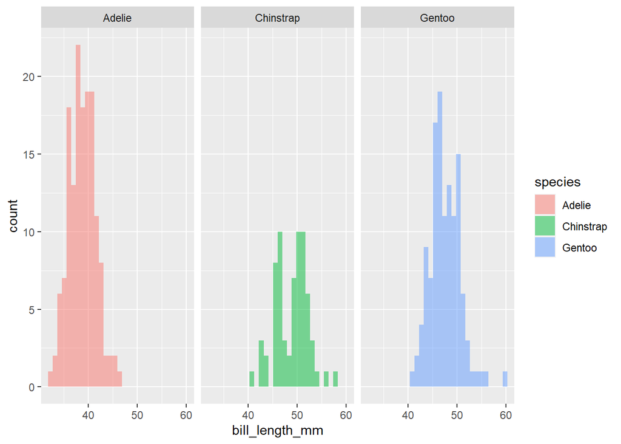

```r
ggplot(data = penguins,
       mapping = aes(x = bill_length_mm,
                     fill = species)) +
  geom_histogram(alpha = 0.5) +
  facet_wrap(facets = vars(species))
```

### Final version

Since the `fill` colours change in the same way as the values on the facets, a legend is not needed in this plot. The legend can be hidden using `theme(legend.position = "none")`. A title, subtitle, caption, and axis titles are set through the `labs()` function. The built-in light {ggplot2} theme is added in here using `theme_light()`.

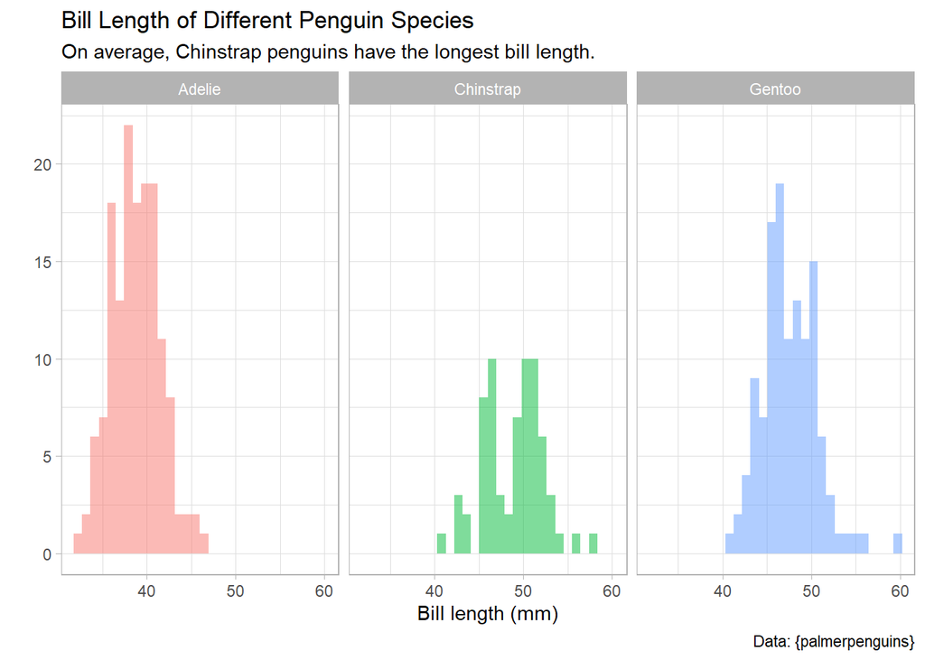

```r
ggplot(data = penguins,
       mapping = aes(x = bill_length_mm,
                     fill = species)) +
  geom_histogram(alpha = 0.5) +
  facet_wrap(~ species) +
  theme_light() +
  labs(title = "Bill Length of Different Penguin Species",
       subtitle = "On average, Chinstrap penguins have the longest bill length.",
       caption = "Data: {palmerpenguins}",
       x = "Bill length (mm)",
       y = "") +
  theme(legend.position = "none")
```